# Simplification Logic for Fuzzy and Crisp Datasets

```r
library(fcaR)
```

# Introduction

This is a simple example of some of the functionalities introduced in package `fcaR`:

- Computing implications and concepts using Ganter’s algorithm.
- Visualization of the concept lattice.
- Removal of redundancies in implications.
- Computation of closures.

# Data

The datasets in this vignette come from [this paper](https://www.sciencedirect.com/science/article/pii/S1877705812021418).

# Crisp Version

The crisp version of the data appears in Table 3 in the mentioned paper.

```r
objects <- paste0("O", 1:6)
n_objects <- length(objects)

attributes <- paste0("P", 1:6)
n_attributes <- length(attributes)

I <- matrix(data = c(0, 1, 1, 0, 0, 1,
                     1, 1, 1, 0, 0, 0,
                     1, 1, 0, 0, 1, 0,
                     1, 0, 0, 1, 1, 0,
                     1, 0, 0, 1, 0, 0,
                     0, 0, 1, 0, 0, 0),
            nrow = n_objects,
            byrow = FALSE)

colnames(I) <- attributes
rownames(I) <- objects
```

## Computing Implications and Concepts

Once we create the formal context object, with the previous data matrix I, we can compute all concepts and implications using Ganter’s algorithm:

```r
fc <- FormalContext$new(I)

# Compute implications
fc$find_implications(verbose = FALSE)

# Cardinality and mean size in the ruleset
fc$implications$cardinality()
```

```
#> [1] 7
```

```r
sizes <- fc$implications$size()
colMeans(sizes)
```

```
#>      LHS      RHS
#> 2.142857 1.857143
```

The obtained implications are:

```r
fc$implications
```

```
#> Implication set with 7 implications.
#> Rule 1: {P6} -> {P1, P2}
#> Rule 2: {P5} -> {P4}
#> Rule 3: {P3, P4, P5} -> {P2}
#> Rule 4: {P2, P4} -> {P3, P5}
#> Rule 5: {P1, P4} -> {P2, P3, P5, P6}
#> Rule 6: {P1, P3} -> {P2}
#> Rule 7: {P1, P2, P3, P6} -> {P4, P5}
```

## Visualization

We provide functions to plot both the concept lattice and the formal context:

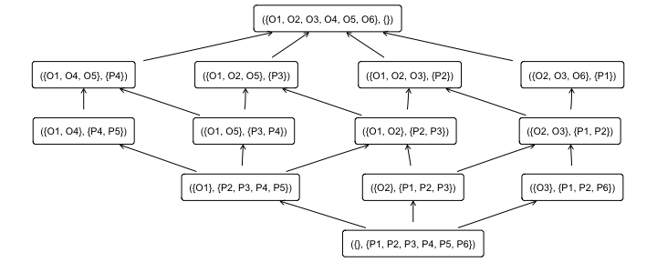

```r
# Visualize the concept lattice
fc$concepts$plot()
```

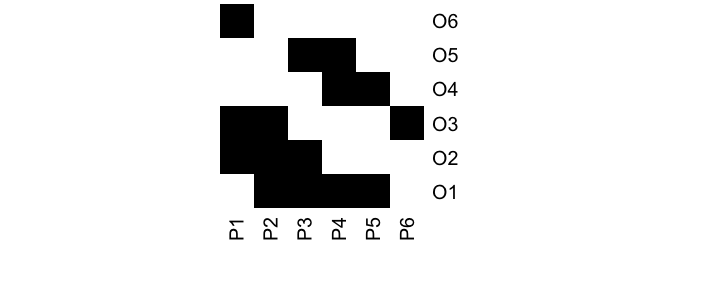

```r
# And the formal context
fc$plot()
```

## Redudancy Removal

Let us apply some simplification rules:

```r
fc$implications$apply_rules(rules = c("composition",
                                      "generalization",
                                      "simplification"),
                            parallelize = FALSE)
```

```
#> Processing batch
#> -->composition: from7to7in0.000999999999997669secs.
#> -->generalization: from7to7in0.00399999999999778secs.
#> -->simplification: from7to7in0.0249999999999986secs.
#> Batch took0.0329999999999941secs.
```

```r
# Compute cardinality and size in the transformed ruleset:
fc$implications$cardinality()
```

```
#> [1] 7
```

```r
sizes <- fc$implications$size()
colMeans(sizes)
```

```
#>      LHS      RHS
#> 1.714286 1.857143
```

The transformed ruleset:

```r
fc$implications
```

```
#> Implication set with 7 implications.
#> Rule 1: {P6} -> {P1, P2}
#> Rule 2: {P5} -> {P4}
#> Rule 3: {P3, P5} -> {P2}
#> Rule 4: {P2, P4} -> {P3, P5}
#> Rule 5: {P1, P4} -> {P2, P3, P5, P6}
#> Rule 6: {P1, P3} -> {P2}
#> Rule 7: {P3, P6} -> {P4, P5}
```

# Fuzzy version

The fuzzy version of the data appears in Table 2 in the mentioned paper.

```r
objects <- paste0("O", 1:6)
n_objects <- length(objects)

attributes <- paste0("P", 1:6)
n_attributes <- length(attributes)

I <- matrix(data = c(0, 1, 0.5, 0, 0, 0.5,
                     1, 1, 0.5, 0, 0, 0,
                     0.5, 1, 0, 0, 1, 0,
                     0.5, 0, 0, 1, 0.5, 0,
                     1, 0, 0, 0.5, 0, 0,
                     0, 0, 1, 0, 0, 0),
            nrow = n_objects,
            byrow = FALSE)

colnames(I) <- attributes
rownames(I) <- objects
```

## Computing Implications and Concepts

As before, we build the formal context object and compute all implications:

```r
fc <- FormalContext$new(I)

# Compute
fc$find_implications(verbose = FALSE)

# Some properties of the ruleset
fc$implications$cardinality()
```

```
#> [1] 12
```

```r
sizes <- fc$implications$size()
colMeans(sizes)
```

```
#>      LHS      RHS
#> 1.541667 1.916667
```

The extracted ruleset is:

```r
fc$implications
```

```
#> Implication set with 12 implications.
#> Rule 1: {P6 [0.5]} -> {P1 [0.5], P2 [0.5], P6}
#> Rule 2: {P5 [0.5]} -> {P4 [0.5]}
#> Rule 3: {P3 [0.5], P4 [0.5], P5 [0.5]} -> {P2, P5}
#> Rule 4: {P3 [0.5], P4} -> {P3}
#> Rule 5: {P2 [0.5], P4 [0.5]} -> {P2, P3 [0.5], P5}
#> Rule 6: {P2 [0.5], P3 [0.5]} -> {P2}
#> Rule 7: {P2, P3, P4 [0.5], P5} -> {P4}
#> Rule 8: {P1 [0.5], P4 [0.5]} -> {P1, P2, P3, P4, P5, P6}
#> Rule 9: {P1 [0.5], P3 [0.5]} -> {P1, P2, P3}
#> Rule 10: {P1 [0.5], P2} -> {P1}
#> Rule 11: {P1, P2 [0.5]} -> {P2}
#> Rule 12: {P1, P2, P3, P6} -> {P4, P5}
```

## Visualization

Let us plot the concept lattice and the formal context.

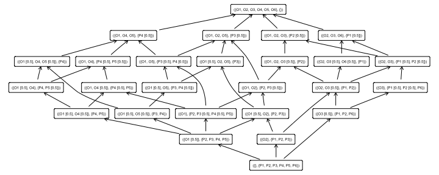

```r
# Visualize the concept lattice
fc$concepts$plot()
```

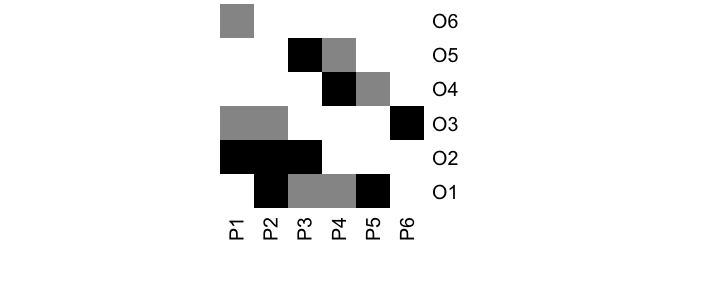

```r
# And the formal context
fc$plot()
```

## Redudancy Removal

Let us apply some functions to remove redudancies in the set of implications:

```r
fc$implications$apply_rules(rules = c("composition"),
                            reorder = FALSE,
                            parallelize = FALSE)
```

```
#> Processing batch
#> -->composition: from12to12in0secs.
#> Batch took0.00300000000000011secs.
```

```r
fc$implications$cardinality()
```

```
#> [1] 12
```

```r
sizes <- fc$implications$size()
colMeans(sizes)
```

```
#>      LHS      RHS
#> 1.541667 1.916667
```

```r
fc$implications$apply_rules(rules = c("simplification"),
                            reorder = FALSE,
                            parallelize = FALSE)
```

```
#> Processing batch
#> -->simplification: from12to12in0.00799999999999557secs.
#> Batch took0.00999999999999801secs.
```

```r
fc$implications$cardinality()
```

```
#> [1] 12
```

```r
sizes <- fc$implications$size()
colMeans(sizes)
```

```
#>      LHS      RHS
#> 1.458333 1.916667
```

```r
fc$implications$apply_rules(rules = c("generalization"),
                            reorder = FALSE,
                            parallelize = FALSE)
```

```
#> Processing batch
#> -->generalization: from12to12in0.00200000000000244secs.
#> Batch took0.00300000000000011secs.
```

```r
fc$implications$cardinality()
```

```
#> [1] 12
```

```r
sizes <- fc$implications$size()
colMeans(sizes)
```

```
#>      LHS      RHS
#> 1.458333 1.916667
```

The reduced ruleset is:

```r
fc$implications
```

```
#> Implication set with 12 implications.
#> Rule 1: {P6 [0.5]} -> {P1 [0.5], P2 [0.5], P6}
#> Rule 2: {P5 [0.5]} -> {P4 [0.5]}
#> Rule 3: {P3 [0.5], P5 [0.5]} -> {P2, P5}
#> Rule 4: {P3 [0.5], P4} -> {P3}
#> Rule 5: {P2 [0.5], P4 [0.5]} -> {P2, P3 [0.5], P5}
#> Rule 6: {P2 [0.5], P3 [0.5]} -> {P2}
#> Rule 7: {P2, P3, P5} -> {P4}
#> Rule 8: {P1 [0.5], P4 [0.5]} -> {P1, P2, P3, P4, P5, P6}
#> Rule 9: {P1 [0.5], P3 [0.5]} -> {P1, P2, P3}
#> Rule 10: {P1 [0.5], P2} -> {P1}
#> Rule 11: {P1, P2 [0.5]} -> {P2}
#> Rule 12: {P1, P2, P3, P6} -> {P4, P5}
```

## Closures

Let us show how to compute the closure of a set S with respect to the implication set.

```r
S <- SparseSet$new(attributes = fc$attributes)
S$assign(P2 = 0.5, P3 = 0.5)
S
```

```
#> {P2 [0.5], P3 [0.5]}
```

```r
fc$implications$closure(S)
```

```
#> $closure
#> {P2, P3 [0.5]}
```